# STAT425_FinalProject

Debapratim Ghosh, Shantanu Solanki

12/9/2021

## Problem Statement

Company XX is a manufacturer of several types of protective packaging, including bubble wrap sold in both retail and bulk. The objective of this project is to determine the best operating conditions for the bubble wrap lines to increase production capacity.

Variables such as extrusion rate, temperature, line speed, and percent loading of additives were key factors that were considered in the study. After preliminary experiments, the engineers decided that line speed, and percent loading of additives were the most significant factors and thus a complete randomized (also called factorial) design was implemented with these two factors:

$$\text{1. Line Speed with levels 36,37 and 38 m/mm}$$
$$\text{2. Loading of Additives with levels 0,2,4 %}$$

The response variable was the `production rate` measured in lbs/hr. The experiment was replicated 3 times and the randomization order for each replication was also recorded. Our goal is to find the optimal combination of line speed and percent load of additives that results in the highest production rate.

The data can be found in the bubblewrap.csv data set on Moodle.

## Analysis Steps

### Loading Required Libraries

```r
library(dplyr)
library(faraway)
library(lmtest)
library(MASS)

library(car)
library(ggplot2)

#library(Metrics)

library(leaps)
```

### Loading the experimental data

```r
df<-read.csv('bubblewrap.csv',header=T)
head(df)
```

```
##   replication run_order line_speed loading rate
## 1           1         6         38       2  240
## 2           1         8         37       4  390
## 3           1         1         36       0  360
## 4           1         9         38       4  400
## 5           1         3         38       0  320
## 6           1         7         36       4  400
```

Here , `loading` and `line_speed` are the factors of the experiment and `rate` is the response.

Before proceeding further let’s convert the `line_speed` and `loading` to factors.

```r
df$line_speed<-as.factor(df$line_speed)
df$loading<-as.factor(df$loading)
```

### Exploring the data

Let’s explore the dataset available to us

```r
dim(df)
```

```
## [1] 27  5
```

So our sample size is 27. Let’s check the number of samples present for each replication

```r
df%>%group_by(replication)%>%count()
```

```
## # A tibble: 3 x 2
## # Groups:   replication [3]
##   replication     n
##         <int> <int>
## 1           1     9
## 2           2     9
## 3           3     9
```

So for each replication we have 9 experimental results.So we have a balanced design.

Let’s get summary statistics of the data:

```r
summary(df)
```

```
##   replication   run_order line_speed loading      rate
##  Min.   :1    Min.   :1   36:9       0:9     Min.   :120.0
##  1st Qu.:1    1st Qu.:3   37:9       2:9     1st Qu.:340.0
##  Median :2    Median :5   38:9       4:9     Median :370.0
##  Mean   :2    Mean   :5                      Mean   :348.9
##  3rd Qu.:3    3rd Qu.:7                      3rd Qu.:390.0
##  Max.   :3    Max.   :9                      Max.   :420.0
```

### Check for difference in response for different levels of factors and presence of interactions

Now, let’s check how the response differs for various factor levels and let’s confirm whether interactions are present or not between the two factors.

```r
multiplot <- function(..., plotlist=NULL, file, cols=1, layout=NULL) {
  library(grid)

  # Make a list from the ... arguments and plotlist
  plots <- c(list(...), plotlist)

  numPlots = length(plots)

  # If layout is NULL, then use 'cols' to determine layout
  if (is.null(layout)) {
    # Make the panel
    # ncol: Number of columns of plots
    # nrow: Number of rows needed, calculated from # of cols
    layout <- matrix(seq(1, cols * ceiling(numPlots/cols)),
                    ncol = cols, nrow = ceiling(numPlots/cols))
  }

 if (numPlots==1) {
    print(plots[[1]])

  } else {
    # Set up the page
    grid.newpage()
    pushViewport(viewport(layout = grid.layout(nrow(layout), ncol(layout))))

    # Make each plot, in the correct location
    for (i in 1:numPlots) {
      # Get the i,j matrix positions of the regions that contain this subplot
      matchidx <- as.data.frame(which(layout == i, arr.ind = TRUE))

      print(plots[[i]], vp = viewport(layout.pos.row = matchidx$row,
                                      layout.pos.col = matchidx$col))
    }
  }
}
```

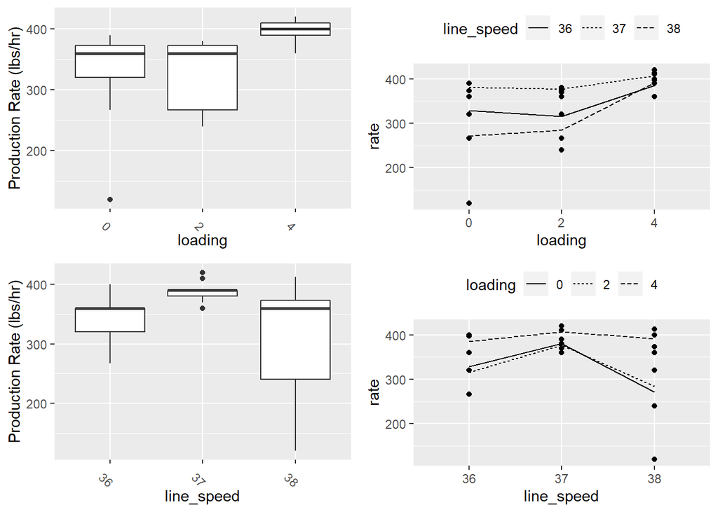

```r
p1 = ggplot(aes(x=loading, y=rate), data=df) +
  geom_boxplot() +
  theme(axis.text.x = element_text(angle=-45)) +
  ylab("Production Rate (lbs/hr)")

p2 = ggplot(aes(x=line_speed, y=rate), data=df) +
  geom_boxplot() +
  theme(axis.text.x = element_text(angle=-45)) +
  ylab("Production Rate (lbs/hr)")

p3 = ggplot(df, aes(x=loading, y=rate)) +
  geom_point() +
  stat_summary(fun="mean", geom="line", aes(group=line_speed, linetype=line_speed))+
  theme(legend.position = "top", legend.direction = "horizontal")

p4 = ggplot(df, aes(x=line_speed, y=rate)) +
  geom_point() +
  stat_summary(fun="mean", geom="line", aes(group=loading, linetype=loading))+
  theme(legend.position = "top", legend.direction = "horizontal")

multiplot(p1, p2, p3, p4, cols=2)
```

**`Rate` being high doesn’t imply that its due to one of the factors. It could be due to random chance. Similarly the presence of interactions doesn’t imply its statistically signficant. We need to test both of the above through 2-way anova models.**

### Two Way Anova Model

Since we are building an ANOVA model, the factor effects model for this problem can be described below :

$$Y_{ijk} = \mu + \alpha_i +\beta_j + (\alpha\beta)_{ij}+\epsilon_{ijk}$$

Where

- $Y_{ijk}$ = Production Rate in lbs/hr
- $\mu$ = mean production rate of bubble wrap across all experimental settings (grand mean)
- $\alpha_i$= Effect of line speed (m/mm) i on production rate of bubble wrap where i =1,2,3
- $\beta_j$= Effect of loading percentage j production rate of bubble wrap where j=1,2,3
- $(\alpha\beta)_{ij}$ = Interaction term between Line Speed i and loading percentage i

The error terms satisfy the assumption $\epsilon_{ijk}$ ~ $\mathcal{N}(0,\sigma^2)$.

Sum Constraints :

- $\sum_{i=1}^{3}\alpha_i$=0
- $\sum_{j=1}^{3}\beta_j$=0
- $\sum_{i}(\alpha\beta)_{ij}=\sum_{j} (\alpha\beta)_{ji}=0$

**Testing for interaction terms**

Let’s fit a model with the interaction between the two factors and perform an ANOVA test on the model to check the significance of interaction .

```r
mod.int<-lm(rate~line_speed*loading,data=df)
summary(mod.int)
```

```
##
## Call:
## lm(formula = rate ~ line_speed * loading, data = df)
##
## Residuals:
##      Min       1Q   Median       3Q      Max
## -151.000  -22.833    4.333   18.167  102.000
##
## Coefficients:
##                       Estimate Std. Error t value Pr(>|t|)
## (Intercept)             329.00      33.66   9.775 1.27e-08 ***
## line_speed37             51.00      47.60   1.071    0.298
## line_speed38            -58.00      47.60  -1.219    0.239
## loading2                -13.33      47.60  -0.280    0.783
## loading4                 56.67      47.60   1.191    0.249
## line_speed37:loading2    10.00      67.31   0.149    0.884
## line_speed38:loading2    26.67      67.31   0.396    0.697
## line_speed37:loading4   -30.00      67.31  -0.446    0.661
## line_speed38:loading4    63.33      67.31   0.941    0.359
## ---
## Signif. codes:  0 '***' 0.001 '**' 0.01 '*' 0.05 '.' 0.1 ' ' 1
##
## Residual standard error: 58.29 on 18 degrees of freedom
## Multiple R-squared:  0.4944, Adjusted R-squared:  0.2697
## F-statistic:   2.2 on 8 and 18 DF,  p-value: 0.07858
```

```r
anova(mod.int)
```

```
## Analysis of Variance Table
##
## Response: rate
##                    Df Sum Sq Mean Sq F value  Pr(>F)
## line_speed          2  23945 11972.3  3.5230 0.05114 .
## loading             2  28022 14011.1  4.1230 0.03357 *
## line_speed:loading  4   7844  1961.1  0.5771 0.68293
## Residuals          18  61169  3398.3
## ---
## Signif. codes:  0 '***' 0.001 '**' 0.01 '*' 0.05 '.' 0.1 ' ' 1
```

Through the ANOVA output we are testing the below hypothesis :

[
$$\begin{cases}
&H_0: (\alpha\beta)_{ij}=0,\forall i,j\\
&H_{\alpha}: \text{ not all } (\alpha\beta)_{ij}=0
\end{cases}$$

]

**Since the p-value of the interaction term is more than our significance level of 5%, we will fail to reject the null and conclude that the interaction term is not significant.**

**Testing for main effects**

Now let’s look at the additive model for production rate with the main effects `line_speed` and `loading`.

```r
additive.mod<-lm(rate~line_speed +loading,data=df)
summary(additive.mod)
```

```
##
## Call:
## lm(formula = rate ~ line_speed + loading, data = df)
##
## Residuals:
##     Min      1Q  Median      3Q     Max
## -173.22  -26.17    8.00   32.78   80.89
##
## Coefficients:
##              Estimate Std. Error t value Pr(>|t|)
## (Intercept)   321.222     24.102  13.327 5.17e-12 ***
## line_speed37   44.333     26.403   1.679   0.1073
## line_speed38  -28.000     26.403  -1.060   0.3004
## loading2       -1.111     26.403  -0.042   0.9668
## loading4       67.778     26.403   2.567   0.0176 *
## ---
## Signif. codes:  0 '***' 0.001 '**' 0.01 '*' 0.05 '.' 0.1 ' ' 1
##
## Residual standard error: 56.01 on 22 degrees of freedom
## Multiple R-squared:  0.4295, Adjusted R-squared:  0.3258
## F-statistic: 4.141 on 4 and 22 DF,  p-value: 0.01192
```

The p-value of the summary of the regression model above is less than 5% which indicates that there is at least one level of factor where the mean production rate is different from the rest. Let’s test each factor against the additive model and check their significance.

**Line Speed**

```r
mod.loading<-lm(rate~loading, data=df)
anova(mod.loading,additive.mod)
```

```
## Analysis of Variance Table
##
## Model 1: rate ~ loading
## Model 2: rate ~ line_speed + loading
##   Res.Df   RSS Df Sum of Sq      F  Pr(>F)
## 1     24 92958
## 2     22 69014  2     23945 3.8165 0.03777 *
## ---
## Signif. codes:  0 '***' 0.001 '**' 0.01 '*' 0.05 '.' 0.1 ' ' 1
```

The above ANOVA output tests the following hypothesis :

[
$$\begin{cases}
&H_0: Y_{ijk} = \mu +\beta_j +\epsilon_{ijk}\\
&H_{\alpha}: Y_{ijk} = \mu + \alpha_i +\beta_j +\epsilon_{ijk}
\end{cases}$$

]

Where

- $\alpha_i$= Effect of line speed (m/mm) i on production rate of bubble wrap where i =1,2,3
- $\beta_j$= Effect of loading percentage j production rate of bubble wrap where j=1,2,3

Now since the p-value is less than our significance level of 5%, we can reject the null hypothesis $H_0$ and conclude that the reduced model with only loading is not adequate and the `line_speed` is a statistically significant factor.

**Loading**

```r
mod.lin.speed<-lm(rate~line_speed, data=df)
anova(mod.lin.speed,additive.mod)
```

```
## Analysis of Variance Table
##
## Model 1: rate ~ line_speed
## Model 2: rate ~ line_speed + loading
##   Res.Df   RSS Df Sum of Sq      F  Pr(>F)
## 1     24 97036
## 2     22 69014  2     28022 4.4664 0.02355 *
## ---
## Signif. codes:  0 '***' 0.001 '**' 0.01 '*' 0.05 '.' 0.1 ' ' 1
```

The above ANOVA output tests the following hypothesis :

[
$$\begin{cases}
&H_0: Y_{ijk} = \mu + \alpha_i +\epsilon_{ijk}\\
&H_{\alpha}: Y_{ijk} = \mu + \alpha_i +\beta_j +\epsilon_{ijk}
\end{cases}$$

]

Where

- $\alpha_i$= Effect of line speed (m/mm) i on production rate of bubble wrap where i =1,2,3
- $\beta_j$= Effect of loading percentage j production rate of bubble wrap where j=1,2,3

Since, the p-value is less than 5% , we can reject the $H_0$ and conclude that the full additive model is adequate and `loading` is a statistically significant factor.

**Therefore, both `loading` and `line_speed` are statistically significant factors and we should consider the additive model as the best model for predicting the response.**

Let’s perform an ANOVA test on our additive model

```r
anova(additive.mod)
```

```
## Analysis of Variance Table
##
## Response: rate
##            Df Sum Sq Mean Sq F value  Pr(>F)
## line_speed  2  23945   11972  3.8165 0.03777 *
## loading     2  28022   14011  4.4664 0.02355 *
## Residuals  22  69014    3137
## ---
## Signif. codes:  0 '***' 0.001 '**' 0.01 '*' 0.05 '.' 0.1 ' ' 1
```

So, as expected, we find that both the factors are statistically significant.

### Checking Model Diagnostics

First, let’s check for outliers using Cook’s distance:

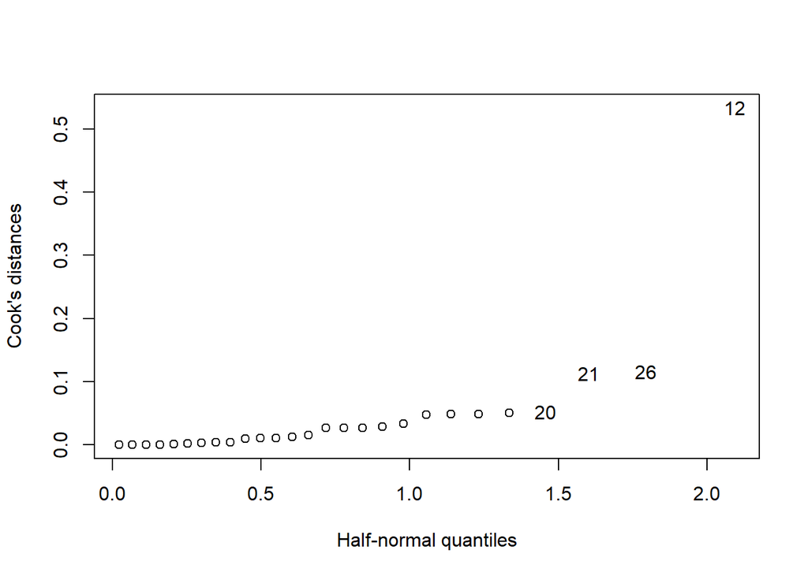

```r
cook = cooks.distance(additive.mod)
halfnorm(cook, 4, labs=as.character(1:length(cook)), ylab="Cook's distances")
```

Since, none of the Cook’s distances is more than 1, we can conclude that we don’t have any outliers/unusual observations.

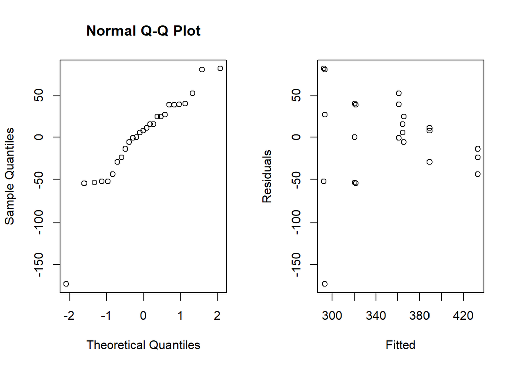

```r
par(mfrow=c(1,2))
qqnorm(additive.mod$res)
plot(additive.mod$fitted, additive.mod$res, xlab="Fitted", ylab="Residuals")
```

Observing the Q-Q plot for residuals we can see that it doesn’t follow a straight line and from the residuals vs fitted plot , we can see that its of a trumpet shape. However, to ascertain if both conditions are met, we need to perform the appropriate hypothesis tests.

We can confirm this by performing the relevant hypothesis tests.

**Breusch-Pagan Test for checking constant variance**

```r
bptest(additive.mod)
```

```
##
##  studentized Breusch-Pagan test
##
## data:  additive.mod
## BP = 7.3817, df = 4, p-value = 0.117
```

We are checking the following hypothesis :

[
$$\begin{cases}
&H_0: \text{Error Variance is constant}\\
&H_{\alpha}: \text{Error Variance is NOT constant}
\end{cases}$$

]

**Since p-value is greater than our significance level of 5% , we fail to reject $H_0$ and conclude that the error variance is constant.**

**Levene Test for checking constant variance**

```r
df$res = additive.mod$residuals
levene = lm(abs(res)~line_speed + loading, data = df)
summary(levene)
```

```
##
## Call:
## lm(formula = abs(res) ~ line_speed + loading, data = df)
##
## Residuals:
##     Min      1Q  Median      3Q     Max
## -49.807  -9.486  -6.251  10.249  96.638
##
## Coefficients:
##              Estimate Std. Error t value Pr(>|t|)
## (Intercept)     45.03      12.85   3.505   0.0020 **
## line_speed37   -11.31      14.07  -0.804   0.4302
## line_speed38    31.56      14.07   2.242   0.0354 *
## loading2       -16.79      14.07  -1.193   0.2456
## loading4       -27.33      14.07  -1.942   0.0650 .
## ---
## Signif. codes:  0 '***' 0.001 '**' 0.01 '*' 0.05 '.' 0.1 ' ' 1
##
## Residual standard error: 29.85 on 22 degrees of freedom
## Multiple R-squared:  0.3856, Adjusted R-squared:  0.2738
## F-statistic: 3.451 on 4 and 22 DF,  p-value: 0.0247
```

```r
anova(levene)
```

```
## Analysis of Variance Table
##
## Response: abs(res)
##            Df  Sum Sq Mean Sq F value Pr(>F)
## line_speed  2  8882.9  4441.5  4.9834 0.0164 *
## loading     2  3420.5  1710.3  1.9190 0.1705
## Residuals  22 19607.4   891.2
## ---
## Signif. codes:  0 '***' 0.001 '**' 0.01 '*' 0.05 '.' 0.1 ' ' 1
```

Since the anova summary shows p-value of greater than 1%, we can’t reject the null hypothesis that the errors have constant variance.

**Shapiro-Wilks Test for checking normality of errors**

```r
shapiro.test(additive.mod$residuals)
```

```
##
##  Shapiro-Wilk normality test
##
## data:  additive.mod$residuals
## W = 0.89977, p-value = 0.01321
```

We are checking the following hypothesis through the above output:

[
$$\begin{cases}
&H_0: \text{Errors are normally distributed}\\
&H_{\alpha}: \text{Error are NOT normally distributed}
\end{cases}$$

]

**Since p-value is less than our significance level of 5%, we can reject the $H_0$ and conclude that the normality assumption is violated.**

In order to make sure that the error variances are normal in nature, we can perform transformation of our response using box cox transformation.

### Box-Cox transformation

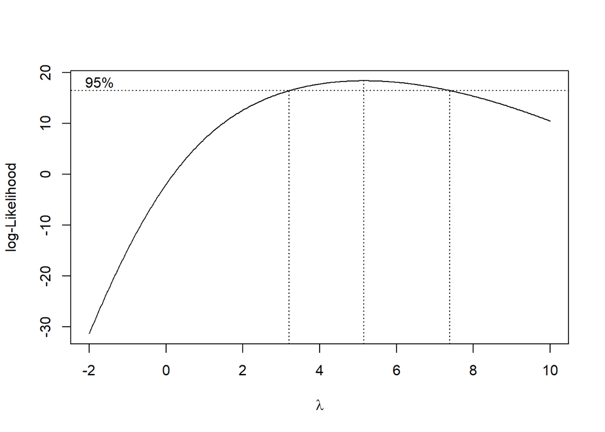

```r
model.transformation<-boxcox(additive.mod,data=df,lambda=seq(-2,10,by=0.025))
```

```r
model.transformation$x[model.transformation$y==max(model.transformation$y)]
```

```
## [1] 5.15
```

```r
tmp=model.transformation$x[model.transformation$y>max(model.transformation$y)-qchisq(0.95,1)/2]

range(tmp)
```

```
## [1] 3.225 7.375
```

So the box-cox transformation is suggesting that we should transform our response to $Rate^5$.

```r
box.additive<-lm(rate^5~line_speed+loading,data=df)
summary(box.additive)
```

```
##
## Call:
## lm(formula = rate^5 ~ line_speed + loading, data = df)
##
## Residuals:
##        Min         1Q     Median         3Q        Max
## -4.010e+12 -2.380e+12  8.833e+11  1.593e+12  3.828e+12
##
## Coefficients:
##                Estimate Std. Error t value Pr(>|t|)
## (Intercept)   4.329e+12  1.053e+12   4.113 0.000458 ***
## line_speed37  3.355e+12  1.153e+12   2.910 0.008125 **
## line_speed38 -2.936e+11  1.153e+12  -0.255 0.801392
## loading2     -6.432e+11  1.153e+12  -0.558 0.582568
## loading4      4.443e+12  1.153e+12   3.853 0.000862 ***
## ---
## Signif. codes:  0 '***' 0.001 '**' 0.01 '*' 0.05 '.' 0.1 ' ' 1
##
## Residual standard error: 2.446e+12 on 22 degrees of freedom
## Multiple R-squared:  0.617,  Adjusted R-squared:  0.5474
## F-statistic:  8.86 on 4 and 22 DF,  p-value: 0.0002026
```

```r
anova(box.additive)
```

```
## Analysis of Variance Table
##
## Response: rate^5
##            Df     Sum Sq    Mean Sq F value    Pr(>F)
## line_speed  2 7.3951e+25 3.6976e+25  6.1808 0.0074105 **
## loading     2 1.3806e+26 6.9032e+25 11.5392 0.0003741 ***
## Residuals  22 1.3161e+26 5.9824e+24
## ---
## Signif. codes:  0 '***' 0.001 '**' 0.01 '*' 0.05 '.' 0.1 ' ' 1
```

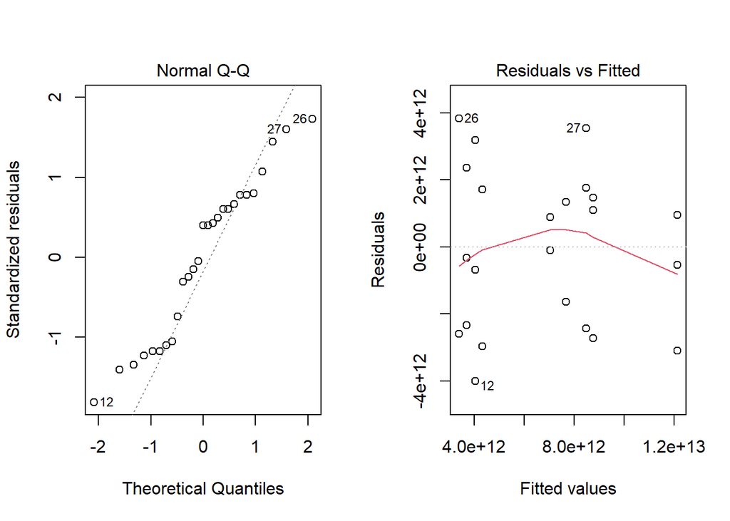

```r
par(mfrow=c(1,2))
#qqnorm(box.additive$res)
#plot(box.additive$fitted, box.additive$res, xlab="Fitted", ylab="Residuals")
plot(box.additive, which = 2)
plot(box.additive, which = 1)
```

**Checking Normality**

```r
shapiro.test(box.additive$residuals)
```

```
##
##  Shapiro-Wilk normality test
##
## data:  box.additive$residuals
## W = 0.94206, p-value = 0.137
```

**Checking Constant Variance through Levene’s test**

```r
#bptest(box.additive)
df$res.box = box.additive$residuals
lm = lm(abs(res.box) ~ line_speed + loading, data = df)
summary(lm)
```

```
##
## Call:
## lm(formula = abs(res.box) ~ line_speed + loading, data = df)
##
## Residuals:
##        Min         1Q     Median         3Q        Max
## -2.193e+12 -3.723e+11  5.457e+09  6.502e+11  1.881e+12
##
## Coefficients:
##                Estimate Std. Error t value Pr(>|t|)
## (Intercept)   1.993e+12  4.092e+11   4.870 7.22e-05 ***
## line_speed37 -6.596e+11  4.483e+11  -1.471   0.1554
## line_speed38  8.794e+11  4.483e+11   1.962   0.0626 .
## loading2     -2.984e+11  4.483e+11  -0.666   0.5126
## loading4     -1.106e+11  4.483e+11  -0.247   0.8074
## ---
## Signif. codes:  0 '***' 0.001 '**' 0.01 '*' 0.05 '.' 0.1 ' ' 1
##
## Residual standard error: 9.51e+11 on 22 degrees of freedom
## Multiple R-squared:  0.359,  Adjusted R-squared:  0.2424
## F-statistic:  3.08 on 4 and 22 DF,  p-value: 0.03717
```